# (Bike_sharing Data Exploration)

```python
## seems that (jan and feb) are less than the others i think due to the weather
```

```python
## making a cutting function
def cutting(col_name):
    return pd.cut(df[col_name], bins=4, labels=['very low','low', 'medium','high'])
df['cut_age']=cutting('age')
df['cut_tripduration']=cutting('tripduration')
```

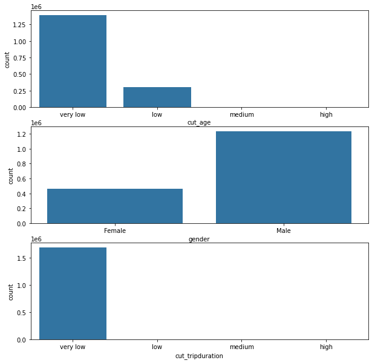

```python
# now if we plotted the age, gender, and duration, is there any relation?.

fig, ax = plt.subplots(nrows=3, figsize = [10,10])

default_color = sb.color_palette()[0]
sb.countplot(data = df, x = 'cut_age', color = default_color, ax = ax[0])
sb.countplot(data = df, x = 'gender', color = default_color, ax = ax[1])
sb.countplot(data = df, x = 'cut_tripduration', color = default_color, ax = ax[2])

plt.show()
```

```python
## checking clients with age over 80
df[df.age > 80]
# 557 record many of them over 100 years old
```

|  | trip_id | bikeid | tripduration | from_station_id | from_station_name | to_station_id | to_station_name | usertype | gender | start_year | start_day | start_month | end_year | end_day | end_month | age | cut_age | cut_tripduration |
| --- | --- | --- | --- | --- | --- | --- | --- | --- | --- | --- | --- | --- | --- | --- | --- | --- | --- | --- |
| 6351 | 21750121 | 4953 | 344.0 | 219 | Damen Ave & Cortland St | 61 | Wood St & Milwaukee Ave | Subscriber | Male | 2019 | Thursday | January | 2019 | Thursday | January | 101 | medium | very low |
| 6423 | 21750195 | 6229 | 1195.0 | 61 | Wood St & Milwaukee Ave | 49 | Dearborn St & Monroe St | Subscriber | Male | 2019 | Thursday | January | 2019 | Thursday | January | 101 | medium | very low |
| 10517 | 21754911 | 668 | 1533.0 | 283 | LaSalle St & Jackson Blvd | 219 | Damen Ave & Cortland St | Subscriber | Male | 2019 | Thursday | January | 2019 | Thursday | January | 101 | medium | very low |
| 10682 | 21755087 | 668 | 892.0 | 219 | Damen Ave & Cortland St | 219 | Damen Ave & Cortland St | Subscriber | Male | 2019 | Thursday | January | 2019 | Thursday | January | 101 | medium | very low |
| 12038 | 21756591 | 5341 | 1316.0 | 58 | Marshfield Ave & Cortland St | 49 | Dearborn St & Monroe St | Subscriber | Male | 2019 | Friday | January | 2019 | Friday | January | 101 | medium | very low |
| ... | ... | ... | ... | ... | ... | ... | ... | ... | ... | ... | ... | ... | ... | ... | ... | ... | ... | ... |
| 1981457 | 25197963 | 4651 | 612.0 | 329 | Lake Shore Dr & Diversey Pkwy | 117 | Wilton Ave & Belmont Ave | Subscriber | Male | 2019 | Sunday | September | 2019 | Sunday | September | 119 | high | very low |
| 1983932 | 25200568 | 2612 | 619.0 | 117 | Wilton Ave & Belmont Ave | 329 | Lake Shore Dr & Diversey Pkwy | Subscriber | Male | 2019 | Sunday | September | 2019 | Sunday | September | 119 | high | very low |
| 1985882 | 25202628 | 5294 | 1057.0 | 158 | Milwaukee Ave & Wabansia Ave | 244 | Ravenswood Ave & Irving Park Rd | Subscriber | Male | 2019 | Sunday | September | 2019 | Sunday | September | 120 | high | very low |
| 1986753 | 25203549 | 5975 | 1352.0 | 298 | Lincoln Ave & Belle Plaine Ave | 158 | Milwaukee Ave & Wabansia Ave | Subscriber | Male | 2019 | Sunday | September | 2019 | Sunday | September | 120 | high | very low |
| 1991412 | 25208515 | 5283 | 1195.0 | 305 | Western Ave & Division St | 230 | Lincoln Ave & Roscoe St | Subscriber | Female | 2019 | Monday | September | 2019 | Monday | September | 86 | medium | very low |

557 rows × 18 columns

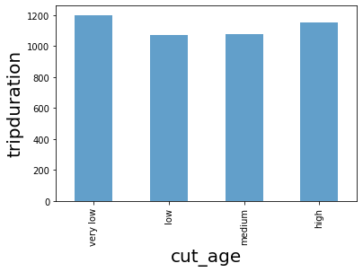

```python
age_dur=df.groupby('cut_age')['tripduration'].mean()
age_dur.plot(kind='bar',alpha=0.7)
plt.xlabel('cut_age',fontsize=20)
plt.ylabel('tripduration',fontsize=20)

## the very low age has the highest tripduration .. but the high age that make higher tripduration doesn't make sense i guess.
```

### Discuss the distribution(s) of your variable(s) of interest. Were there any unusual points? Did you need to perform any transformations?

> It seems that males bikers are more than females, bikers within 20 - 40 in age are the most common users, also found that the subscribers are more than daily clients.

> Also found that the customers prefe al the days of the week except the weekend .. few ride in weekend.

> As well as the riders are very few in winter than other seasons.

### Of the features you investigated, were there any unusual distributions? Did you perform any operations on the data to tidy, adjust, or change the form of the data? If so, why did you do this?

> The tripduration distribution was confusing i had to change the way to plot it correctly .. also it was object .. had to convert it into float to work on it.

> but found that the very low age has the highest tripduration .. but the high age that make higher tripduration doesn't make sense i guess.

## Bivariate Exploration

> In this section, investigate relationships between pairs of variables in your data. Make sure the variables that you cover here have been introduced in some fashion in the previous section (univariate exploration).

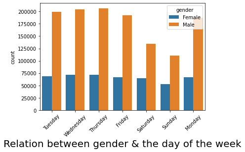

```python
## checking the relation between the gender and the day of the week
sb.countplot(data = df, x='start_day', hue='gender')
plt.xticks(rotation=45);
plt.xlabel('Relation between gender & the day of the week', fontsize=20);
```

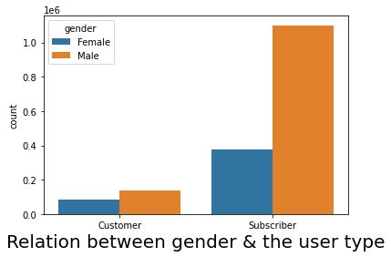

```python
## checking the relation between the gender and the user type
sb.countplot(data = df, x='usertype', hue='gender')
plt.xlabel('Relation between gender & the user type', fontsize=20);

# seems that most of the subscribers and daily customers are males
```

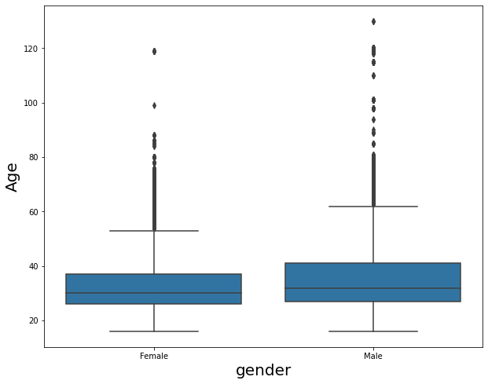

```python
plt.figure(figsize=[10, 8])
sb.boxplot(data=df, x='gender', y='age', color=base_color);
plt.xlabel('gender', fontsize=20);
plt.ylabel('Age', fontsize=20);
```

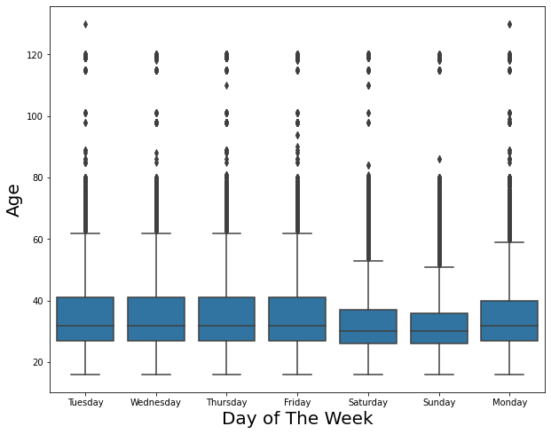

```python
## using box plot
plt.figure(figsize=[10, 8])
sb.boxplot(data=df, x='start_day', y='age', color=base_color);
plt.xlabel('Day of The Week', fontsize=20);
plt.ylabel('Age', fontsize=20);

# most of the riders are in the range of 20 - 40 in age mostly distributed in the whole week except the weekend but, thoese who rides in weekends are mostly the younger ones
```

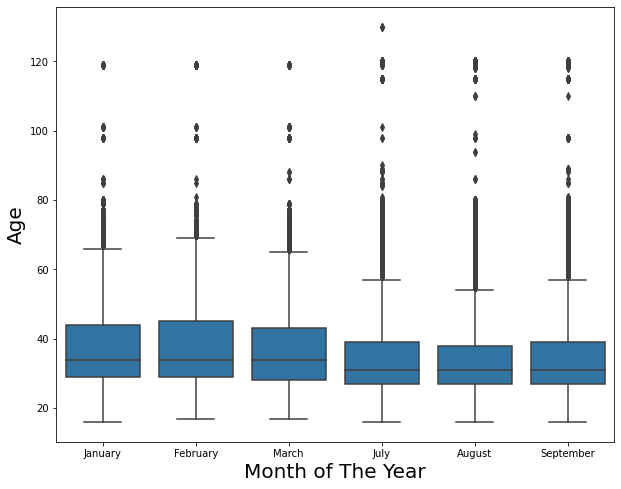

```python
## using box plot
plt.figure(figsize=[10, 8])
sb.boxplot(data=df, x='start_month', y='age', color=base_color);
plt.xlabel('Month of The Year', fontsize=20);
plt.ylabel('Age', fontsize=20);

# seems the riders with young age bike in summer than elders that rides in all months including winter
```

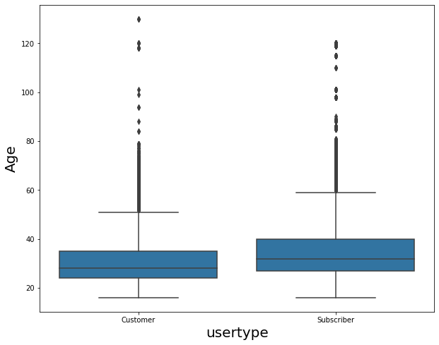

```python
plt.figure(figsize=[10, 8])
sb.boxplot(data=df, x='usertype', y='age', color=base_color);
plt.xlabel('usertype', fontsize=20);
plt.ylabel('Age', fontsize=20);
```

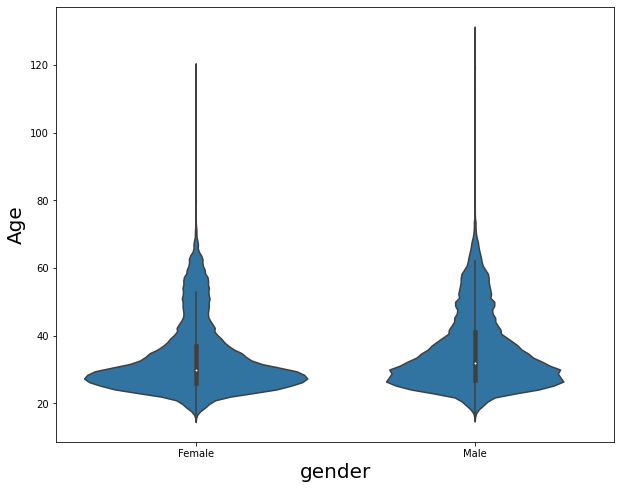

```python
## using violin plot
plt.figure(figsize=[10, 8])
sb.violinplot(data=df, x='gender', y='age', color=base_color);
plt.xlabel('gender', fontsize=20);
plt.ylabel('Age', fontsize=20);

# the distribution of the young age in females is wider than males
```

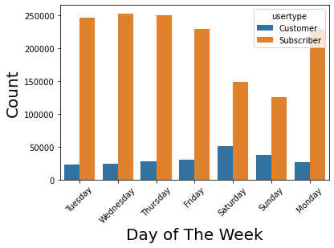

```python
## relation between days of the week and usertype
sb.countplot(data=df, x='start_day', hue='usertype');
plt.xlabel('Day of The Week', fontsize=20);
plt.xticks(rotation=45);
plt.ylabel('Count', fontsize=20);

# subscribers rides more the whole week and less in weekends, on the other hand customers rides more in weekends
```

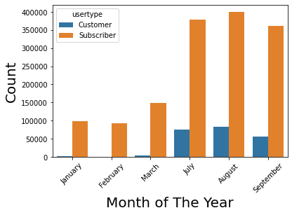

```python
## relation between days of the week and usertype
sb.countplot(data=df, x='start_month', hue='usertype');
plt.xlabel('Month of The Year', fontsize=20);
plt.xticks(rotation=45);
plt.ylabel('Count', fontsize=20);

# subscribers as well as customers prefer riding in summer than winter and their peak of riding in (August)
```

```python
# now let's check the pairwise correlations present between features in the data
numeric_vars = ['age', 'tripduration']
categoric_vars = ['gender', 'usertype', 'start_day', 'start_month']
```

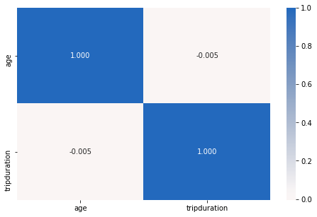

```python
# correlation plot
plt.figure(figsize = [8, 5])
sb.heatmap(df[numeric_vars].corr(), annot = True, fmt = '.3f', cmap = 'vlag_r', center = 0)
plt.show()
```

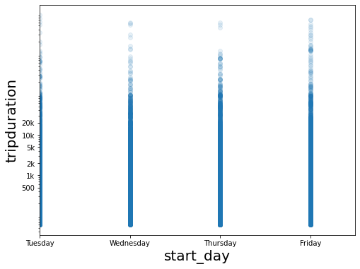

```python
# scatter plot of tripduration vs. start_day, with log transform on tripduration axis

plt.figure(figsize = [8, 6])
plt.scatter(data = df, x = 'start_day', y = 'tripduration', alpha = 1/10)
plt.xlim([0, 3.5])
plt.xlabel('start_day', fontsize=20)
plt.yscale('log')
plt.yticks([500, 1e3, 2e3, 5e3, 1e4, 2e4], [500, '1k', '2k', '5k', '10k', '20k'])
plt.ylabel('tripduration', fontsize=20)
plt.show()
```

### Talk about some of the relationships you observed in this part of the investigation. How did the feature(s) of interest vary with other features in the dataset?

> Both females and males prefer riding in work days than weekends, and both are more subscribers than usual customers, but males are more bikers than females, although female bikers are mostly younger than male ones.

> most of the riders are in the range of 20 - 40 in age mostly distributed in the whole week except the weekend but, thoese who rides in weekends are mostly the younger ones.

> It seems also that riders with young age ride in summer than elders that ride in all seasons.

> Subescribers are older in age than usual customers, on the other hand subscribers ride in the ordinary work days more than weekends. However, usual customers prefer weekends more.

> subscribers as well as customers prefer riding in summer than winter and their peak of riding in (August).

### Did you observe any interesting relationships between the other features (not the main feature(s) of interest)?

> female bikers are younger than male ones while both prefer riding in summer than winter, subscribers are older than customers and unlike customers they prefer riding in work days than weekends!

## Multivariate Exploration

> Create plots of three or more variables to investigate your data even further. Make sure that your investigations are justified, and follow from your work in the previous sections.

[figure not shown]

```python
fig, ax = plt.subplots(ncols = 2, figsize = [12,6])

sb.barplot(data = df, x = 'gender', y = 'age', hue = 'start_day',
             palette = 'Blues', dodge = 0.5, ax = ax[0])
ax[0].set_title('Age VS Gender according Usertype')
ax[0].set_ylabel('Age in years')

sb.barplot(data = df, x = 'gender', y = 'age', hue = 'start_month',
             palette = 'Blues', dodge = 0.5, ax = ax[1])
ax[1].set_title('Age VS Day according Month')
ax[1].set_ylabel('Age in years')
plt.xticks(rotation=45);
plt.show();
```

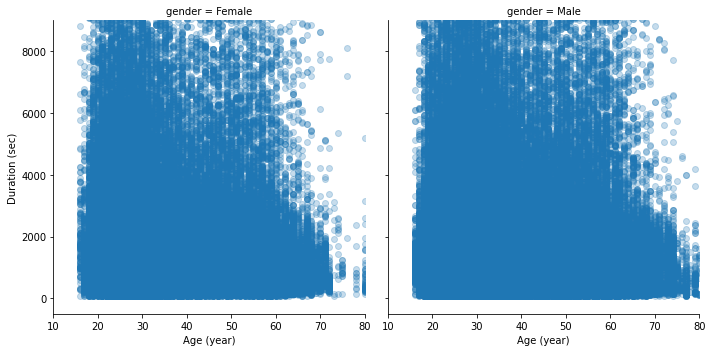

```python
genders = sb.FacetGrid(data = df, col = 'gender', col_wrap = 2, size = 5,
                 xlim = [10, 80], ylim = [-500, 9000])
genders.map(plt.scatter, 'age', 'tripduration', alpha=0.25)
genders.set_xlabels('Age (year)')
genders.set_ylabels('Duration (sec)')

plt.show()
```

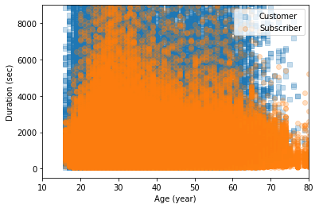

```python
user_type_markers = [['Customer', 's'],['Subscriber', 'o']]

for utype, marker in user_type_markers:
    df_utype = df[df['usertype'] == utype]
    plt.scatter((df_utype['age']), df_utype['tripduration'], marker = marker, alpha=0.25)
plt.legend(['Customer','Subscriber'])
plt.axis([10, 80, -500, 9000 ])
plt.xlabel('Age (year)')
plt.ylabel('Duration (sec)')
plt.show()
```

### Talk about some of the relationships you observed in this part of the investigation. Were there features that strengthened each other in terms of looking at your feature(s) of interest?

> Here the higher durationtrips are for males more than females, but the females are mostly younger than males. For different user types both are showing similer trends for age and tripduration. but it seems that customers rides durations more than subscribers.

### Were there any interesting or surprising interactions between features?

> I think the difference between males and females in using the system according to age and tripduration is quite interisting!

> At the end of your report, make sure that you export the notebook as an html file from the `File > Download as... > HTML` menu. Make sure you keep track of where the exported file goes, so you can put it in the same folder as this notebook for project submission. Also, make sure you remove all of the quote-formatted guide notes like this one before you finish your report!